# Felt loneliness

# 1 Description of DataSchema variable

The description of harmonised variables is the following:

- Short name: `loneliness`
- Variable label: `felt loneliness?`
- Domain: `Social environment`
- Value type: `categorical`
- Categories:

| **Code** | **Category Label** |
| --- | --- |
| 0 | No |
| 1 | Yes |

- Category missings:

| **Code** | **Category Label** |
| --- | --- |
| 991 | CAPI/interviewer error |
| 992 | Impute |
| 993 | Disable to measure |
| 994 | Not attempt/not done |
| 995 | Does not answer |
| 996 | Not applicable |
| 997 | Refuse |
| 998 | Do not know |
| 999 | Missing |

# 2 Data process

## 2.1 England

### 2.1.1 Wave 1

#### 2.1.1.1 Study-specific variable description

The study-specific variable elected to be harmonised is:

- Name: `PSCEDE`
- Label: `Much of the time during the past week, have you felt loneliness?`
- Categories:
  - `1 = Yes`
  - `2 = No`
- Missings:
  - `-9 = Refusal`
  - `-8 = Don't Know`
  - `-1 = Not applicable`
- Description:

PSCEDE

| Sample size | Missing values |
| --- | --- |
| 12099 | 383 |

Category

|  | 1 | 2 |
| --- | --- | --- |
| Frequency | 1595.00 | 10121.00 |
| Percentage | 13.18 | 83.65 |

Type of missing

|  | -9 | -8 | -1 | NA |
| --- | --- | --- | --- | --- |
| Frequency | 44.00 | 28.00 | 311.00 | 0 |
| Percentage | 0.36 | 0.23 | 2.57 | 0 |

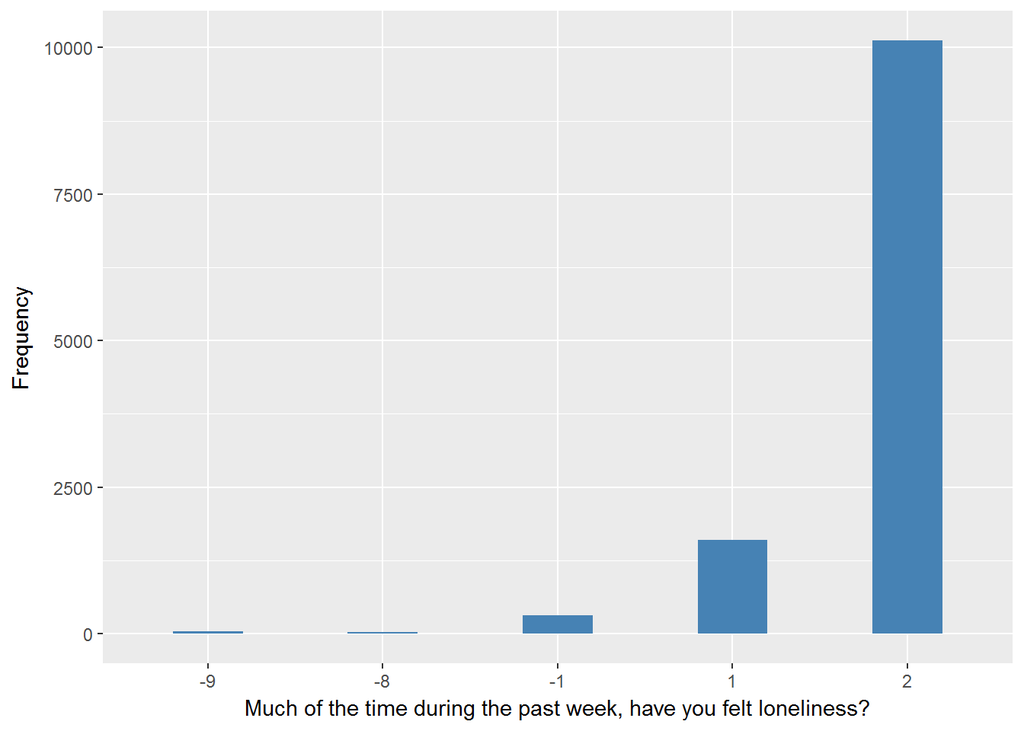

#### 2.1.1.2 Harmonisation algorithm

To compute the harmonize variable from the study-specific variable it has to be recoded as follows:

- `1 into 1`
- `2 into 0`
- `-9 into 997; -8 into 998; -1 into 996`
- `NA into 999`

**R script:**

```r
ELSA_ds_w1 <- tibble(id = ELSA_w1_loneliness$id)
ELSA_ds_w1$loneliness <- car::recode(as.vector(ELSA_w1_loneliness$pscede), "1='1'; 2='0'; -9='997'; -8='998'; -1='996'; NA='999'")
ELSA_ds_w1$loneliness <- labelled(ELSA_ds_w1$loneliness, labels = c(No = 0,
    Yes = 1, Missing = 999, `Do not know` = 998, Refuse = 997, `Not applicable` = 996,
    `Don't answer` = 995, `Not attempt/not done/not yet recorded` = 994, `Disable to measure` = 993,
    Impute = 992, `CAPI/interviewer error` = 991))
```

#### 2.1.1.3 Statistical description of the new harmonised variable

| Sample size | Missing values |
| --- | --- |
| 12099 | 383 |

Category

|  | 0 | 1 |
| --- | --- | --- |
| Frequency | 10121.00 | 1595.00 |
| Percentage | 83.65 | 13.18 |

Type of missing

|  | 991 | 992 | 993 | 994 | 995 | 996 | 997 | 998 | 999 | NA |
| --- | --- | --- | --- | --- | --- | --- | --- | --- | --- | --- |
| Frequency | 0 | 0 | 0 | 0 | 0 | 311.00 | 44.00 | 28.00 | 0 | 0 |
| Percentage | 0 | 0 | 0 | 0 | 0 | 2.57 | 0.36 | 0.23 | 0 | 0 |

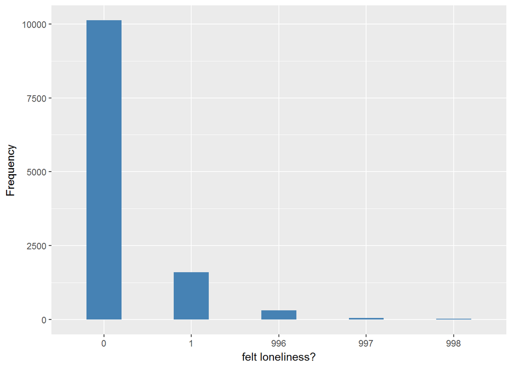

#### 2.1.1.4 Validation

|  | 2->0 | 1->1 | -1->996 | -9->997 | -8->998 |
| --- | --- | --- | --- | --- | --- |
| BeforeH | 10121 | 1595 | 311 | 44 | 28 |
| AfterH | 10121 | 1595 | 311 | 44 | 28 |

### 2.1.2 Wave 2

#### 2.1.2.1 Study-specific variable description

The study-specific variable elected to be harmonised is:

- Name: `PSCEDE`
- Label: `Much of the time during the past week, have you felt loneliness?`
- Categories:
  - `1 = Yes`
  - `2 = No`
- Missings:
  - `-9 = Refusal`
  - `-8 = Don't Know`
  - `-1 = Not applicable`
- Description:

PSCEDE

| Sample size | Missing values |
| --- | --- |
| 9432 | 216 |

Category

|  | 1 | 2 |
| --- | --- | --- |
| Frequency | 1275.00 | 7941.00 |
| Percentage | 13.52 | 84.19 |

Type of missing

|  | -9 | -8 | -1 | NA |
| --- | --- | --- | --- | --- |
| Frequency | 23.00 | 34.00 | 159.00 | 0 |
| Percentage | 0.24 | 0.36 | 1.69 | 0 |

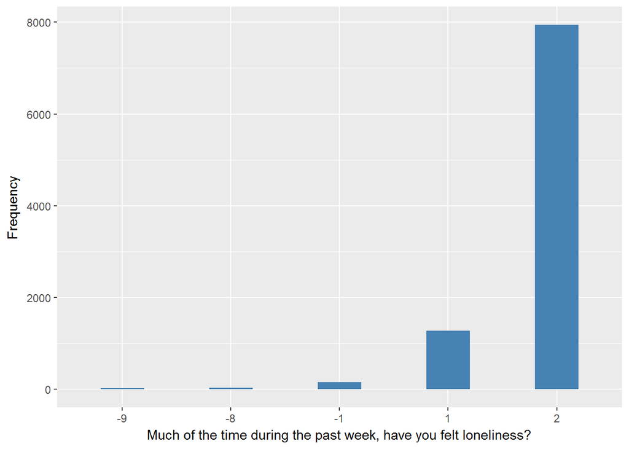

#### 2.1.2.2 Harmonisation algorithm

To compute the harmonize variable from the study-specific variable it has to be recoded as follows:

- `1 into 1`
- `2 into 0`
- `-9 into 997; -8 into 998; -1 into 996`
- `NA into 999`

**R script:**

```r
ELSA_ds_w2 <- tibble(id = ELSA_w2_loneliness$id)
ELSA_ds_w2$loneliness <- car::recode(as.vector(ELSA_w2_loneliness$PScedE), "1='1'; 2='0'; -9='997'; -8='998'; -1='996'; NA='999'")
ELSA_ds_w2$loneliness <- labelled(ELSA_ds_w2$loneliness, labels = c(No = 0,
    Yes = 1, Missing = 999, `Do not know` = 998, Refuse = 997, `Not applicable` = 996,
    `Don't answer` = 995, `Not attempt/not done/not yet recorded` = 994, `Disable to measure` = 993,
    Impute = 992, `CAPI/interviewer error` = 991))
```

#### 2.1.2.3 Statistical description of the new harmonised variable

| Sample size | Missing values |
| --- | --- |
| 9432 | 216 |

Category

|  | 0 | 1 |
| --- | --- | --- |
| Frequency | 7941.00 | 1275.00 |
| Percentage | 84.19 | 13.52 |

Type of missing

|  | 991 | 992 | 993 | 994 | 995 | 996 | 997 | 998 | 999 | NA |
| --- | --- | --- | --- | --- | --- | --- | --- | --- | --- | --- |
| Frequency | 0 | 0 | 0 | 0 | 0 | 159.00 | 23.00 | 34.00 | 0 | 0 |
| Percentage | 0 | 0 | 0 | 0 | 0 | 1.69 | 0.24 | 0.36 | 0 | 0 |

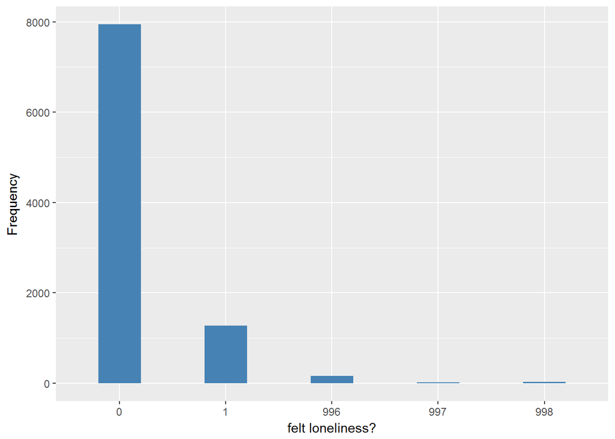

#### 2.1.2.4 Validation

|  | 2->0 | 1->1 | -1->996 | -9->997 | -8->998 |
| --- | --- | --- | --- | --- | --- |
| BeforeH | 7941 | 1275 | 159 | 23 | 34 |
| AfterH | 7941 | 1275 | 159 | 23 | 34 |

### 2.1.3 Wave 3

#### 2.1.3.1 Study-specific variable description

The study-specific variable elected to be harmonised is:

- Name: `PSCEDE`
- Label: `Much of the time during the past week, have you felt loneliness?`
- Categories:
  - `1 = Yes`
  - `2 = No`
- Missings:
  - `-9 = Refusal`
  - `-8 = Don't Know`
  - `-2 = Schedule not applicable`
  - `-1 = Not applicable`
- Description:

PSCEDE

| Sample size | Missing values |
| --- | --- |
| 9771 | 312 |

Category

|  | 1 | 2 |
| --- | --- | --- |
| Frequency | 1252.00 | 8207.00 |
| Percentage | 12.81 | 83.99 |

Type of missing

|  | -9 | -8 | -2 | -1 | NA |
| --- | --- | --- | --- | --- | --- |
| Frequency | 12.00 | 24.00 | 0 | 276.00 | 0 |
| Percentage | 0.12 | 0.25 | 0 | 2.82 | 0 |

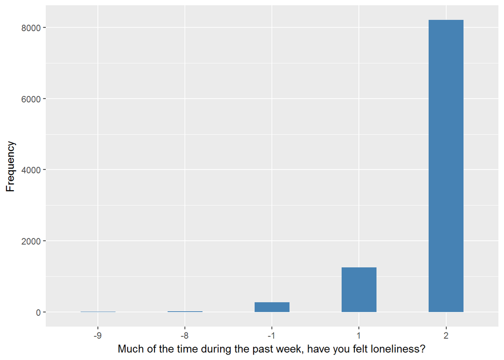

#### 2.1.3.2 Harmonisation algorithm

To compute the harmonize variable from the study-specific variable it has to be recoded as follows:

- `1 into 1`
- `2 into 0`
- `-9 into 997; -8 into 998; -1 or -2 into 996`
- `NA into 999`

**R script:**

```r
ELSA_ds_w3 <- tibble(id = ELSA_w3_loneliness$id)
ELSA_ds_w3$loneliness <- car::recode(as.vector(ELSA_w3_loneliness$pscede), "1='1'; 2='0'; -9='997'; -8='998'; -1='996'; -2='996'; NA='999'")
ELSA_ds_w3$loneliness <- labelled(ELSA_ds_w3$loneliness, labels = c(No = 0,
    Yes = 1, Missing = 999, `Do not know` = 998, Refuse = 997, `Not applicable` = 996,
    `Don't answer` = 995, `Not attempt/not done/not yet recorded` = 994, `Disable to measure` = 993,
    Impute = 992, `CAPI/interviewer error` = 991))
```

#### 2.1.3.3 Statistical description of the new harmonised variable

| Sample size | Missing values |
| --- | --- |
| 9771 | 312 |

Category

|  | 0 | 1 |
| --- | --- | --- |
| Frequency | 8207.00 | 1252.00 |
| Percentage | 83.99 | 12.81 |

Type of missing

|  | 991 | 992 | 993 | 994 | 995 | 996 | 997 | 998 | 999 | NA |
| --- | --- | --- | --- | --- | --- | --- | --- | --- | --- | --- |
| Frequency | 0 | 0 | 0 | 0 | 0 | 276.00 | 12.00 | 24.00 | 0 | 0 |
| Percentage | 0 | 0 | 0 | 0 | 0 | 2.82 | 0.12 | 0.25 | 0 | 0 |

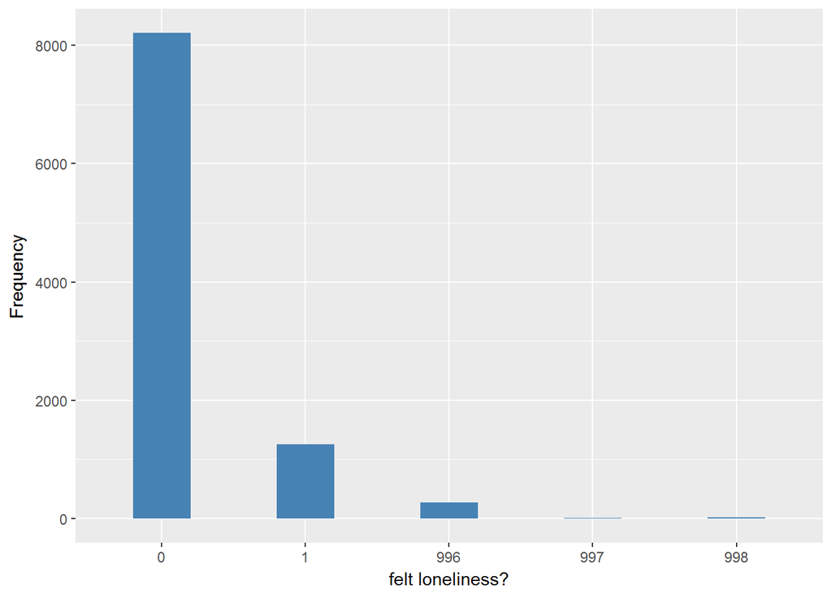

#### 2.1.3.4 Validation

|  | 2->0 | 1->1 | -1->996 | -9->997 | -8->998 |
| --- | --- | --- | --- | --- | --- |
| BeforeH | 8207 | 1252 | 276 | 12 | 24 |
| AfterH | 8207 | 1252 | 276 | 12 | 24 |

### 2.1.4 Wave 4

#### 2.1.4.1 Study-specific variable description

The study-specific variable elected to be harmonised is:

- Name: `pscede`
- Label: `Much of the time during the past week, have you felt loneliness?`
- Categories:
  - `1 = Yes`
  - `2 = No`
- Missings:
  - `-9 = Refusal`
  - `-8 = Don't Know`
  - `-2 = Schedule not applicable`
  - `-1 = Not applicable`
- Description:

PSCEDE

| Sample size | Missing values |
| --- | --- |
| 11050 | 522 |

Category

|  | 1 | 2 |
| --- | --- | --- |
| Frequency | 1340.00 | 9188.00 |
| Percentage | 12.13 | 83.15 |

Type of missing

|  | -9 | -8 | -2 | -1 | NA |
| --- | --- | --- | --- | --- | --- |
| Frequency | 61.00 | 15.00 | 0 | 446.00 | 0 |
| Percentage | 0.55 | 0.14 | 0 | 4.04 | 0 |

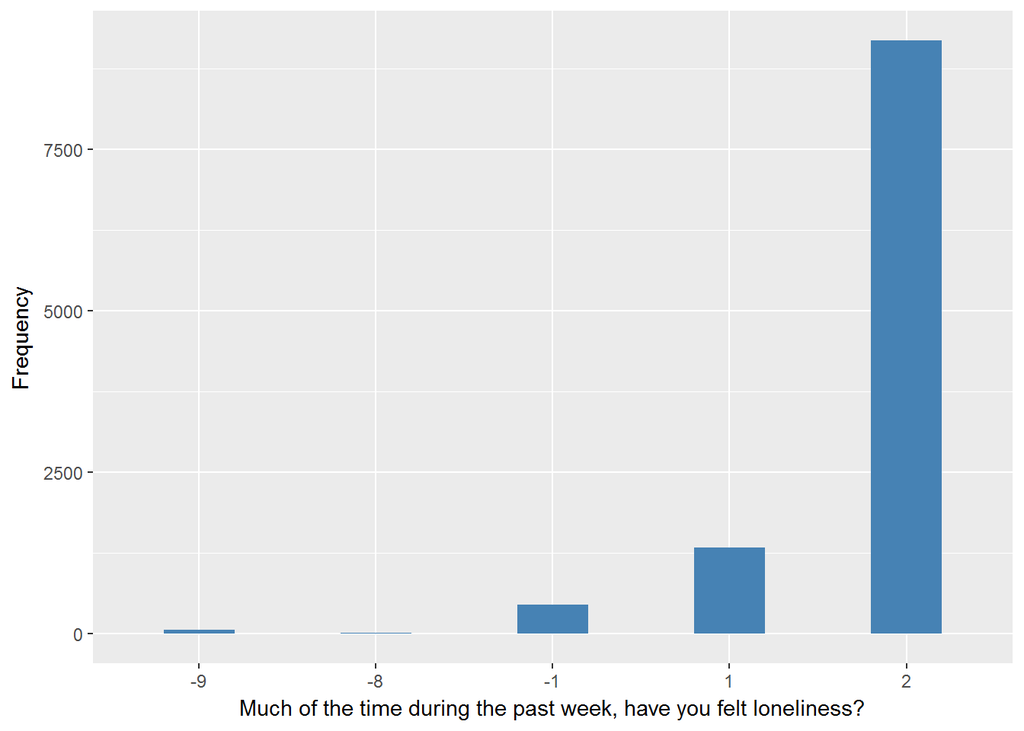

#### 2.1.4.2 Harmonisation algorithm

To compute the harmonize variable from the study-specific variable it has to be recoded as follows:

- `1 into 1`
- `2 into 0`
- `-9 into 997; -8 into 998; -1 or -2 into 996`
- `NA into 999`

**R script:**

```r
ELSA_ds_w4 <- tibble(id = ELSA_w4_loneliness$id)
ELSA_ds_w4$loneliness <- car::recode(as.vector(ELSA_w4_loneliness$pscede), "1='1'; 2='0'; -9='997'; -8='998'; -1='996'; -2='996'; NA='999'")
ELSA_ds_w4$loneliness <- labelled(ELSA_ds_w4$loneliness, labels = c(No = 0,
    Yes = 1, Missing = 999, `Do not know` = 998, Refuse = 997, `Not applicable` = 996,
    `Don't answer` = 995, `Not attempt/not done/not yet recorded` = 994, `Disable to measure` = 993,
    Impute = 992, `CAPI/interviewer error` = 991))
```

#### 2.1.4.3 Statistical description of the new harmonised variable

| Sample size | Missing values |
| --- | --- |
| 11050 | 522 |

Category

|  | 0 | 1 |
| --- | --- | --- |
| Frequency | 9188.00 | 1340.00 |
| Percentage | 83.15 | 12.13 |

Type of missing

|  | 991 | 992 | 993 | 994 | 995 | 996 | 997 | 998 | 999 | NA |
| --- | --- | --- | --- | --- | --- | --- | --- | --- | --- | --- |
| Frequency | 0 | 0 | 0 | 0 | 0 | 446.00 | 61.00 | 15.00 | 0 | 0 |
| Percentage | 0 | 0 | 0 | 0 | 0 | 4.04 | 0.55 | 0.14 | 0 | 0 |

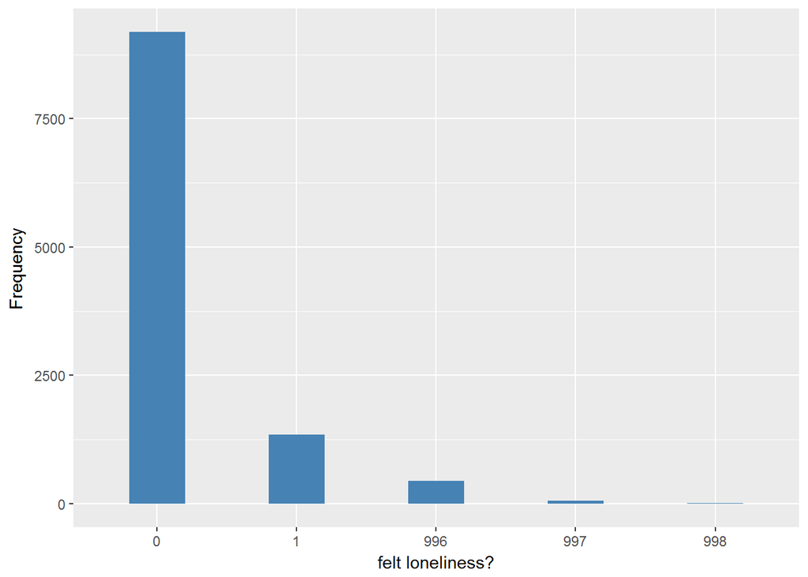

#### 2.1.4.4 Validation

|  | 2->0 | 1->1 | -1->996 | -9->997 | -8->998 |
| --- | --- | --- | --- | --- | --- |
| BeforeH | 9188 | 1340 | 446 | 61 | 15 |
| AfterH | 9188 | 1340 | 446 | 61 | 15 |

### 2.1.5 Wave 5

#### 2.1.5.1 Study-specific variable description

The study-specific variable elected to be harmonised is:

- Name: `pscede`
- Label: `Much of the time during the past week, have you felt loneliness?`
- Categories:
  - `1 = Yes`
  - `2 = No`
- Missings:
  - `-9 = Refusal`
  - `-8 = Don't Know`
  - `-2 = Schedule not applicable`
  - `-1 = Item not applicable`
- Description:

PSCEDE

| Sample size | Missing values |
| --- | --- |
| 10274 | 624 |

Category

|  | 1 | 2 |
| --- | --- | --- |
| Frequency | 1253.0 | 8397.00 |
| Percentage | 12.2 | 81.73 |

Type of missing

|  | -9 | -8 | -2 | -1 | NA |
| --- | --- | --- | --- | --- | --- |
| Frequency | 25.00 | 62.0 | 0 | 537.00 | 0 |
| Percentage | 0.24 | 0.6 | 0 | 5.23 | 0 |

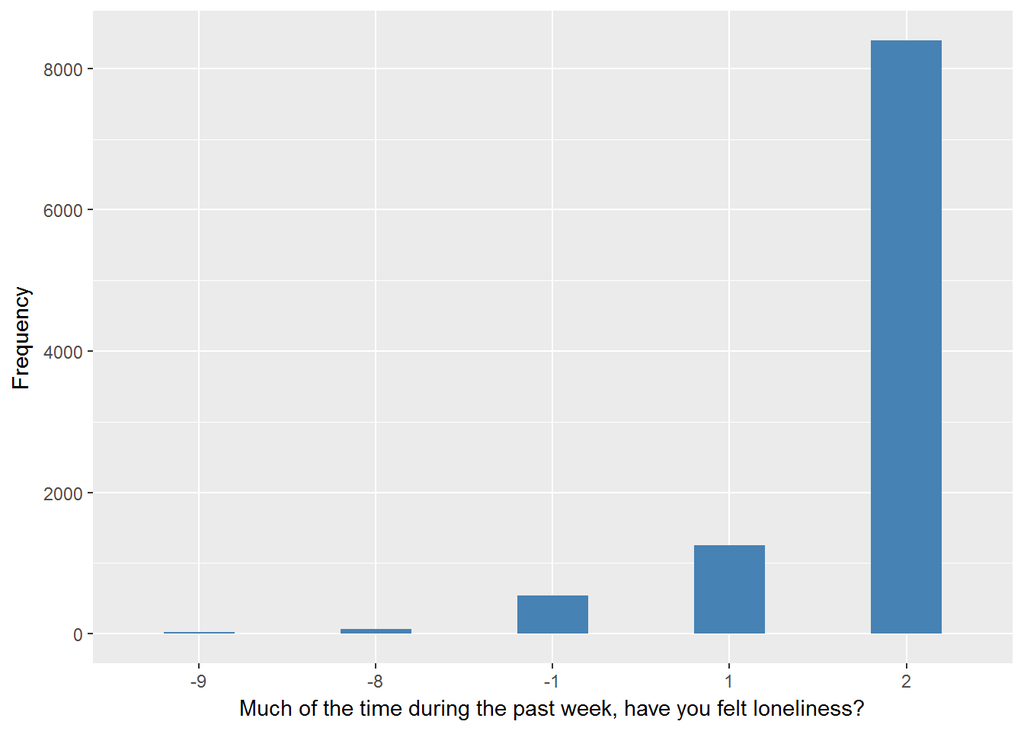

#### 2.1.5.2 Harmonisation algorithm

To compute the harmonize variable from the study-specific variable it has to be recoded as follows:

- `1 into 1`
- `2 into 0`
- `-9 into 997; -8 into 998; -1 or -2 into 996`
- `NA into 999`

**R script:**

```r
ELSA_ds_w5 <- tibble(id = ELSA_w5_loneliness$id)
ELSA_ds_w5$loneliness <- car::recode(as.vector(ELSA_w5_loneliness$pscede), "1='1'; 2='0'; -9='997'; -8='998'; -1='996'; -2='996'; NA='999'")
ELSA_ds_w5$loneliness <- labelled(ELSA_ds_w5$loneliness, labels = c(No = 0,
    Yes = 1, Missing = 999, `Do not know` = 998, Refuse = 997, `Not applicable` = 996,
    `Don't answer` = 995, `Not attempt/not done/not yet recorded` = 994, `Disable to measure` = 993,
    Impute = 992, `CAPI/interviewer error` = 991))
```

#### 2.1.5.3 Statistical description of the new harmonised variable

| Sample size | Missing values |
| --- | --- |
| 10274 | 624 |

Category

|  | 0 | 1 |
| --- | --- | --- |
| Frequency | 8397.00 | 1253.0 |
| Percentage | 81.73 | 12.2 |

Type of missing

|  | 991 | 992 | 993 | 994 | 995 | 996 | 997 | 998 | 999 | NA |
| --- | --- | --- | --- | --- | --- | --- | --- | --- | --- | --- |
| Frequency | 0 | 0 | 0 | 0 | 0 | 537.00 | 25.00 | 62.0 | 0 | 0 |
| Percentage | 0 | 0 | 0 | 0 | 0 | 5.23 | 0.24 | 0.6 | 0 | 0 |

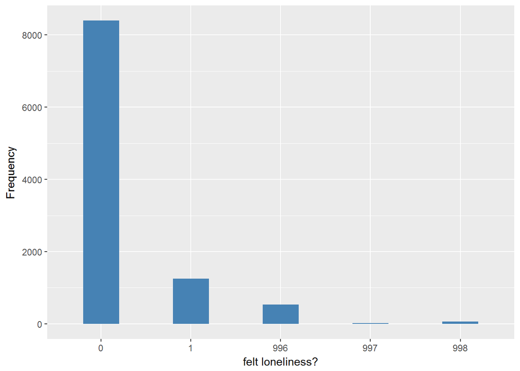

#### 2.1.5.4 Validation

|  | 2->0 | 1->1 | -1->996 | -9->997 | -8->998 |
| --- | --- | --- | --- | --- | --- |
| BeforeH | 8397 | 1253 | 537 | 25 | 62 |
| AfterH | 8397 | 1253 | 537 | 25 | 62 |

### 2.1.6 Wave 6

#### 2.1.6.1 Study-specific variable description

The study-specific variable elected to be harmonised is:

- Name: `PScedE`
- Label: `Much of the time during the past week, have you felt loneliness?`
- Categories:
  - `1 = Yes`
  - `2 = No`
- Missings:
  - `-9 = Refusal`
  - `-8 = Don't Know`
  - `-2 = Schedule not applicable`
  - `-1 = Item not applicable`
- Description:

PSCEDE

| Sample size | Missing values |
| --- | --- |
| 10601 | 687 |

Category

|  | 1 | 2 |
| --- | --- | --- |
| Frequency | 1146.00 | 8768.00 |
| Percentage | 10.81 | 82.71 |

Type of missing

|  | -9 | -8 | -2 | -1 | NA |
| --- | --- | --- | --- | --- | --- |
| Frequency | 28.00 | 32.0 | 0 | 627.00 | 0 |
| Percentage | 0.26 | 0.3 | 0 | 5.91 | 0 |

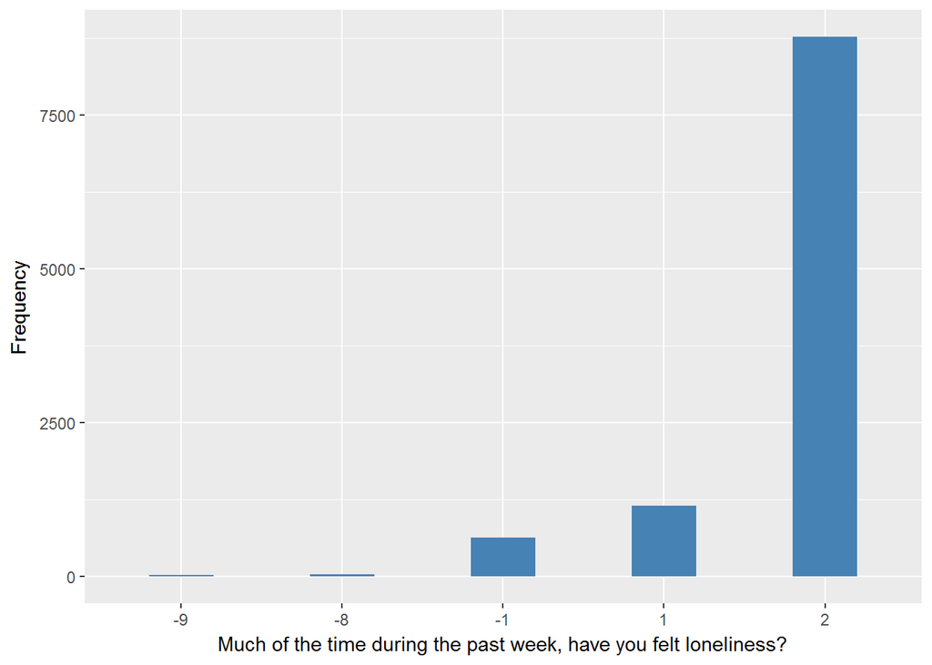

#### 2.1.6.2 Harmonisation algorithm

To compute the harmonize variable from the study-specific variable it has to be recoded as follows:

- `1 into 1`
- `2 into 0`
- `-9 into 997; -8 into 998; -1 or -2 into 996`
- `NA into 999`

**R script:**

```r
ELSA_ds_w6 <- tibble(id = ELSA_w6_loneliness$id)
ELSA_ds_w6$loneliness <- car::recode(as.vector(ELSA_w6_loneliness$PScedE), "1='1'; 2='0'; -9='997'; -8='998'; -1='996'; -2='996'; NA='999'")
ELSA_ds_w6$loneliness <- labelled(ELSA_ds_w6$loneliness, labels = c(No = 0,
    Yes = 1, Missing = 999, `Do not know` = 998, Refuse = 997, `Not applicable` = 996,
    `Don't answer` = 995, `Not attempt/not done/not yet recorded` = 994, `Disable to measure` = 993,
    Impute = 992, `CAPI/interviewer error` = 991))
```

#### 2.1.6.3 Statistical description of the new harmonised variable

| Sample size | Missing values |
| --- | --- |
| 10601 | 687 |

Category

|  | 0 | 1 |
| --- | --- | --- |
| Frequency | 8768.00 | 1146.00 |
| Percentage | 82.71 | 10.81 |

Type of missing

|  | 991 | 992 | 993 | 994 | 995 | 996 | 997 | 998 | 999 | NA |
| --- | --- | --- | --- | --- | --- | --- | --- | --- | --- | --- |
| Frequency | 0 | 0 | 0 | 0 | 0 | 627.00 | 28.00 | 32.0 | 0 | 0 |
| Percentage | 0 | 0 | 0 | 0 | 0 | 5.91 | 0.26 | 0.3 | 0 | 0 |

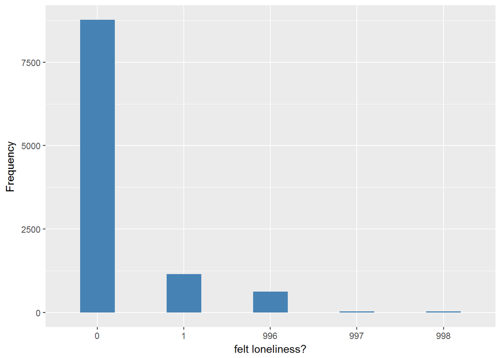

#### 2.1.6.4 Validation

|  | 2->0 | 1->1 | -1->996 | -9->997 | -8->998 |
| --- | --- | --- | --- | --- | --- |
| BeforeH | 8768 | 1146 | 627 | 28 | 32 |
| AfterH | 8768 | 1146 | 627 | 28 | 32 |

### 2.1.7 Wave 7

#### 2.1.7.1 Study-specific variable description

The study-specific variable elected to be harmonised is:

- Name: `PScedE`
- Label: `Much of the time during the past week, have you felt loneliness?`
- Categories:
  - `1 = Yes`
  - `2 = No`
- Missings:
  - `-9 = Refusal`
  - `-8 = Don't Know`
  - `-2 = Schedule not applicable`
  - `-1 = Item not applicable`
- Description:

| Sample size | Missing values |
| --- | --- |
| 9666 | 671 |

Category

|  | 1 | 2 |
| --- | --- | --- |
| Frequency | 959.00 | 8036.00 |
| Percentage | 9.92 | 83.14 |

Type of missing

|  | -9 | -8 | -2 | -1 | NA |
| --- | --- | --- | --- | --- | --- |
| Frequency | 51.00 | 23.00 | 0 | 597.00 | 0 |
| Percentage | 0.53 | 0.24 | 0 | 6.18 | 0 |

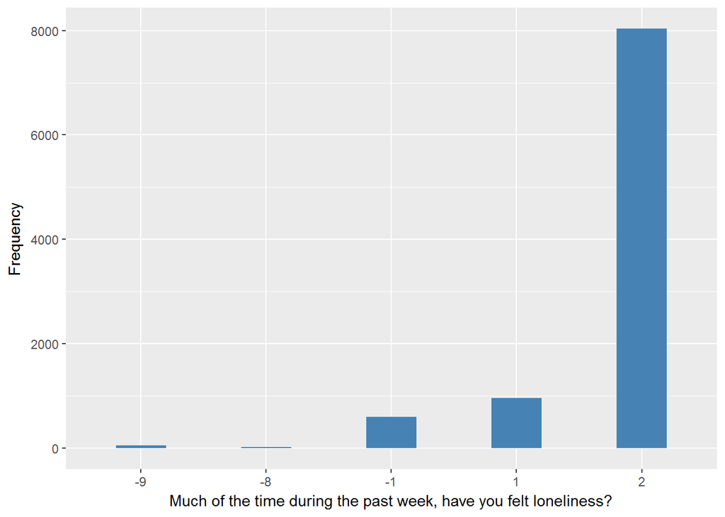

#### 2.1.7.2 Harmonisation algorithm

To compute the harmonize variable from the study-specific variable it has to be recoded as follows:

- `1 into 1`
- `2 into 0`
- `-9 into 997; -8 into 998; -1 or -2 into 996`
- `NA into 999`

**R script:**

```r
ELSA_ds_w7 <- tibble(id = ELSA_w7_loneliness$id)
ELSA_ds_w7$loneliness <- car::recode(as.vector(ELSA_w7_loneliness$PScedE), "1='1'; 2='0'; -9='997'; -8='998'; -1='996'; -2='996'; NA='999'")
ELSA_ds_w7$loneliness <- labelled(ELSA_ds_w7$loneliness, labels = c(No = 0,
    Yes = 1, Missing = 999, `Do not know` = 998, Refuse = 997, `Not applicable` = 996,
    `Don't answer` = 995, `Not attempt/not done/not yet recorded` = 994, `Disable to measure` = 993,
    Impute = 992, `CAPI/interviewer error` = 991))
```

#### 2.1.7.3 Statistical description of the new harmonised variable

| Sample size | Missing values |
| --- | --- |
| 9666 | 671 |

Category

|  | 0 | 1 |
| --- | --- | --- |
| Frequency | 8036.00 | 959.00 |
| Percentage | 83.14 | 9.92 |

Type of missing

|  | 991 | 992 | 993 | 994 | 995 | 996 | 997 | 998 | 999 | NA |
| --- | --- | --- | --- | --- | --- | --- | --- | --- | --- | --- |
| Frequency | 0 | 0 | 0 | 0 | 0 | 597.00 | 51.00 | 23.00 | 0 | 0 |
| Percentage | 0 | 0 | 0 | 0 | 0 | 6.18 | 0.53 | 0.24 | 0 | 0 |

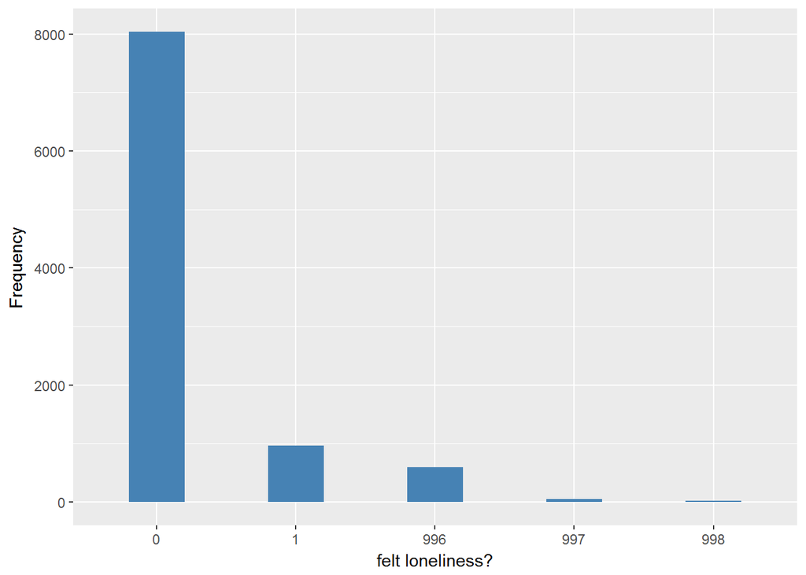

#### 2.1.7.4 Validation

|  | 2->0 | 1->1 | -1->996 | -9->997 | -8->998 |
| --- | --- | --- | --- | --- | --- |
| BeforeH | 8036 | 959 | 597 | 51 | 23 |
| AfterH | 8036 | 959 | 597 | 51 | 23 |

# 3 Quality estimation